# 02数据操作

# dplyr 包

```r
library(dplyr)
```

管道函数 %>% ：Ctrl+Shift+M

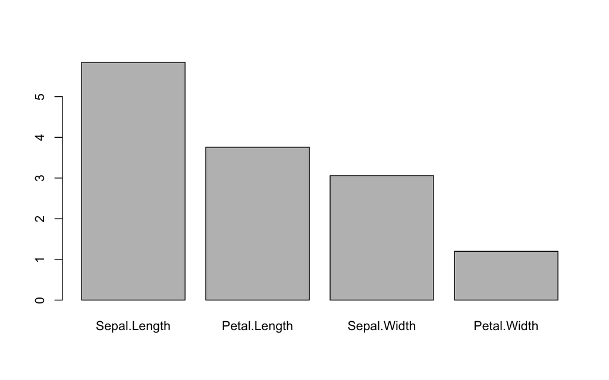

```r
iris %>% select(-Species) %>% apply(2,mean) %>%
  sort(decreasing = T) %>% barplot()
```

```r
iris %>% select(-Species) %>% apply(2,mean) -> result
result
## Sepal.Length  Sepal.Width Petal.Length  Petal.Width
##     5.843333     3.057333     3.758000     1.199333
```

```r
iris %>% select(-Species) %>% summary()
##   Sepal.Length    Sepal.Width     Petal.Length    Petal.Width
##  Min.   :4.300   Min.   :2.000   Min.   :1.000   Min.   :0.100
##  1st Qu.:5.100   1st Qu.:2.800   1st Qu.:1.600   1st Qu.:0.300
##  Median :5.800   Median :3.000   Median :4.350   Median :1.300
##  Mean   :5.843   Mean   :3.057   Mean   :3.758   Mean   :1.199
##  3rd Qu.:6.400   3rd Qu.:3.300   3rd Qu.:5.100   3rd Qu.:1.800
##  Max.   :7.900   Max.   :4.400   Max.   :6.900   Max.   :2.500
```

管道操作中dot(.)的应用

```r
cname <- c("Sepal.Length","Species")
df <- iris %>% .[,colnames(.) %in% cname] # . 表示左边的输入iris
head(df)
##   Sepal.Length Species
## 1          5.1  setosa
## 2          4.9  setosa
## 3          4.7  setosa
## 4          4.6  setosa
## 5          5.0  setosa
## 6          5.4  setosa
```

管道操作 |>

### select函数

```r
# 通过管道操作选择多列数据
iris %>% select(c("Sepal.Length","Sepal.Width")) %>% head(3)
##   Sepal.Length Sepal.Width
## 1          5.1         3.5
## 2          4.9         3.0
## 3          4.7         3.2
```

```r
# 选择变量名以"Petal"开始的变量
iris %>% select(starts_with("Petal")) %>% head(3)
##   Petal.Length Petal.Width
## 1          1.4         0.2
## 2          1.4         0.2
## 3          1.3         0.2
```

```r
# 选择变量名以"length"结尾的变量
iris %>% select(ends_with("Length")) %>% head(3)
##   Sepal.Length Petal.Length
## 1          5.1          1.4
## 2          4.9          1.4
## 3          4.7          1.3
```

```r
# 选择变量名包含"p"的变量
iris %>% select(contains("p")) %>% head(3)
##   Sepal.Length Sepal.Width Petal.Length Petal.Width Species
## 1          5.1         3.5          1.4         0.2  setosa
## 2          4.9         3.0          1.4         0.2  setosa
## 3          4.7         3.2          1.3         0.2  setosa
```

```r
# 使用冒号(:)选择变量
iris %>% select(Sepal.Length:Petal.Length) %>% head(3)
##   Sepal.Length Sepal.Width Petal.Length
## 1          5.1         3.5          1.4
## 2          4.9         3.0          1.4
## 3          4.7         3.2          1.3
```

```r
# 使用!选择变量
iris %>% select(!(Species)) %>% head(3)
##   Sepal.Length Sepal.Width Petal.Length Petal.Width
## 1          5.1         3.5          1.4         0.2
## 2          4.9         3.0          1.4         0.2
## 3          4.7         3.2          1.3         0.2
```

```r
library(dplyr)
```

### select + filter

```r
mtcars %>% select(!carb) %>% filter(am == 1) %>% head(3)
##                mpg cyl disp  hp drat    wt  qsec vs am gear
## Mazda RX4     21.0   6  160 110 3.90 2.620 16.46  0  1    4
## Mazda RX4 Wag 21.0   6  160 110 3.90 2.875 17.02  0  1    4
## Datsun 710    22.8   4  108  93 3.85 2.320 18.61  1  1    4
```

```r
mtcars %>% select(!carb) %>% filter(between(mpg,10,20 )) %>% head(3)
##                    mpg cyl disp  hp drat   wt  qsec vs am gear
## Hornet Sportabout 18.7   8  360 175 3.15 3.44 17.02  0  0    3
## Valiant           18.1   6  225 105 2.76 3.46 20.22  1  0    3
## Duster 360        14.3   8  360 245 3.21 3.57 15.84  0  0    3
```

逻辑或

```r
mtcars %>% select(!carb) %>% filter(mpg>10 | disp>100) %>% head(3)
##                mpg cyl disp  hp drat    wt  qsec vs am gear
## Mazda RX4     21.0   6  160 110 3.90 2.620 16.46  0  1    4
## Mazda RX4 Wag 21.0   6  160 110 3.90 2.875 17.02  0  1    4
## Datsun 710    22.8   4  108  93 3.85 2.320 18.61  1  1    4
```

& 逻辑与

```r
mtcars %>% select(!carb) %>% filter(mpg>20 & disp>100) %>% head(3)
##                mpg cyl disp  hp drat    wt  qsec vs am gear
## Mazda RX4     21.0   6  160 110 3.90 2.620 16.46  0  1    4
## Mazda RX4 Wag 21.0   6  160 110 3.90 2.875 17.02  0  1    4
## Datsun 710    22.8   4  108  93 3.85 2.320 18.61  1  1    4
```

### 分组(group_by)

```r
mtcars %>% group_by(factor(cyl)) %>% summarise(n=n(),meanmpg=mean(mpg),meansd=sd(mpg)) %>% mutate(mpgse=meansd/sqrt(n)) %>% arrange(desc(mpgse)) %>% head(6)
## # A tibble: 3 × 5
##   `factor(cyl)`     n meanmpg meansd mpgse
##   <fct>         <int>   <dbl>  <dbl> <dbl>
## 1 4                11    26.7   4.51 1.36
## 2 8                14    15.1   2.56 0.684
## 3 6                 7    19.7   1.45 0.549
```

- across函数

accross(.cols=,.fns=,.names=) + .cols用于我们选取的若干列 + .fns指定要执行的函数 + .names设置输出列的命名情况

```r
mtcars %>% group_by(factor(cyl)) %>%
  summarise(n=n(),across(mpg:wt,mean,.names = "mean_{.col}")) %>% head(6)
## # A tibble: 3 × 8
##   `factor(cyl)`     n mean_mpg mean_cyl mean_disp mean_hp mean_drat mean_wt
##   <fct>         <int>    <dbl>    <dbl>     <dbl>   <dbl>     <dbl>   <dbl>
## 1 4                11     26.7        4      105.    82.6      4.07    2.29
## 2 6                 7     19.7        6      183.   122.       3.59    3.12
## 3 8                14     15.1        8      353.   209.       3.23    4.00
```

- 计算多列的均值和标准差

```r
mtcars %>% group_by(factor(cyl)) %>%
  summarise(n=n(),across(mpg:wt,list(mean=mean,sd=sd))) %>% head(6)
## # A tibble: 3 × 14
##   `factor(cyl)`     n mpg_mean mpg_sd cyl_mean cyl_sd disp_mean disp_sd hp_mean
##   <fct>         <int>    <dbl>  <dbl>    <dbl>  <dbl>     <dbl>   <dbl>   <dbl>
## 1 4                11     26.7   4.51        4      0      105.    26.9    82.6
## 2 6                 7     19.7   1.45        6      0      183.    41.6   122.
## 3 8                14     15.1   2.56        8      0      353.    67.8   209.
## # ℹ 5 more variables: hp_sd <dbl>, drat_mean <dbl>, drat_sd <dbl>,
## #   wt_mean <dbl>, wt_sd <dbl>
```

- ungroup 消除数据中的分组变量

```r
mtcars %>% group_by(factor(cyl)) %>%
  summarise(n=n(),across(mpg:wt,list(mean=mean,sd=sd))) %>%
  ungroup() %>%
  sample_n(size = 3,replace = F)
## # A tibble: 3 × 14
##   `factor(cyl)`     n mpg_mean mpg_sd cyl_mean cyl_sd disp_mean disp_sd hp_mean
##   <fct>         <int>    <dbl>  <dbl>    <dbl>  <dbl>     <dbl>   <dbl>   <dbl>
## 1 8                14     15.1   2.56        8      0      353.    67.8   209.
## 2 4                11     26.7   4.51        4      0      105.    26.9    82.6
## 3 6                 7     19.7   1.45        6      0      183.    41.6   122.
## # ℹ 5 more variables: hp_sd <dbl>, drat_mean <dbl>, drat_sd <dbl>,
## #   wt_mean <dbl>, wt_sd <dbl>
```

- 分组计算线性回归模型

```r
mtcars %>%
  group_split(cyl) %>%
  map(~lm(mpg~wt,data=.x))
## [[1]]
##
## Call:
## lm(formula = mpg ~ wt, data = .x)
##
## Coefficients:
## (Intercept)           wt
##      39.571       -5.647
##
##
## [[2]]
##
## Call:
## lm(formula = mpg ~ wt, data = .x)
##
## Coefficients:
## (Intercept)           wt
##       28.41        -2.78
##
##
## [[3]]
##
## Call:
## lm(formula = mpg ~ wt, data = .x)
##
## Coefficients:
## (Intercept)           wt
##      23.868       -2.192
```

```r
dfs <- iris %>% group_split(Species)
files <- str_c("../Input/data/",levels(iris$Species),".csv")
walk2(dfs,files,write.csv,row.names=F)
```

首先要得到导入的全部Excel的完整路径，可以任意嵌套，只需将recurse设为TRUE

用map_dfr在该路径向量上进行迭代，把read.csv应用到每个文件再按行合并

用set_names()将文件路径字符向量创建为命名向量，再结合”.id”将路径值作为数据来源列

```r
files <- fs::dir_ls("../Input/data/",recurse = T,glob = "*.csv")
df <- map_dfr(set_names(files),read.csv,.id = "来源")
head(df)
##                       来源 Sepal.Length Sepal.Width Petal.Length Petal.Width
## 1 ../Input/data/setosa.csv          5.1         3.5          1.4         0.2
## 2 ../Input/data/setosa.csv          4.9         3.0          1.4         0.2
## 3 ../Input/data/setosa.csv          4.7         3.2          1.3         0.2
## 4 ../Input/data/setosa.csv          4.6         3.1          1.5         0.2
## 5 ../Input/data/setosa.csv          5.0         3.6          1.4         0.2
## 6 ../Input/data/setosa.csv          5.4         3.9          1.7         0.4
##   Species
## 1  setosa
## 2  setosa
## 3  setosa
## 4  setosa
## 5  setosa
## 6  setosa
```

## 数据融合

```r
m1 <- mtcars %>% mutate(id=rownames(.)) %>% select(mpg:hp,id) %>%
  sample_n(size = 22,replace = F)
m2 <- mtcars %>% mutate(id=rownames(.)) %>%
  select(wt,qsec,id) %>%
  sample_n(size = 15,replace = F)
```

- left_join

left_join(x,y)表示将数据框x,y根据左边数据表x的内容进行融合

```r
mydata1 <- left_join(m1,m2,by="id")
```

- right_join

right_join(x,y)表示将数据框x,y根据右边数据表x的内容进行融合

```r
mydata2 <- right_join(m1,m2,by="id")
```

- full_join

full_join(x,y)表示将数据框x,y进行融合时，返回两个数据表中的所有内容

```r
mydata3 <- full_join(m1,m2,by="id")
```

- inner_join

```r
mydata4 <- inner_join(m1,m2,by="id")
```

## 长宽数据转换

```r
library(tidyr)
iris %>% gather(key = "category",value = "Length",Sepal.Length:Petal.Width) %>% head(3)
##   Species     category Length
## 1  setosa Sepal.Length    5.1
## 2  setosa Sepal.Length    4.9
## 3  setosa Sepal.Length    4.7
```

# lubridate包处理时间数据

```r
library(lubridate)
```

```r
today()
```

```
## [1] "2024-07-23"
```

```r
now()
```

```
## [1] "2024-07-23 14:16:37 CST"
```

```r
as_datetime(today())
```

```
## [1] "2024-07-23 UTC"
```

```r
as_date(now())
```

```
## [1] "2024-07-23"
```

- 通过年-月-日解析时间

```r
ymd(c("2022-4-1","2022,5,1","20220601","2022年7月1日"))
## [1] "2022-04-01" "2022-05-01" "2022-06-01" "2022-07-01"
```

- 获取年份信息

```r
year("2022-4-1")
## [1] 2022
```

- 创建日期时间

```r
d <- make_date(2020,8,27)
d
## [1] "2020-08-27"
```

```r
make_datetime(2020,8,27,21,27,15)
## [1] "2020-08-27 21:27:15 UTC"
```

```r
# 格式化输出日期
format(d,"%Y/%m/%d")
## [1] "2020/08/27"
```

```r
# stamp函数，按给定模板格式输出日期时间
fmt <- stamp("Created on Sunday,Jan 1,1999")
fmt(d)
## [1] "Created on Thursday,Aug 27,2020"
```

- 按照时间阶梯

```r
seq.Date(as_date("2019-02-01"),by="month",length.out = 3)
## [1] "2019-02-01" "2019-03-01" "2019-04-01"
```

- 计算时间之间的间隔

```r
time1 <- ymd_hms("2022-2-10 14:44:30")
time2 <- ymd_hms("2022-10-12 1:44:3")
# 创建时间间隔对象
timeinv <- interval(time1,time2)
# 获取间隔时间间隔多少天
time_length(timeinv,unit = "day")
## [1] 243.458
```